# Education in Developing Nations: Understanding Lower Secondary School Completion Rates

Author

Léo COSNIER

# Education in Developing Nations:

## Understanding Lower Secondary School Completion Rates

Education is a key driver of economic and social development. However, in many developing and emerging countries, lower secondary school completion rates remain a challenge due to factors such as poverty, gender inequality, and conflict.

This dashboard is built around **UNICEF’s indicator** for **lower secondary school completion rate**. It represents:

*The percentage of a cohort of children or young people aged 3-5 years above the intended age for the last grade of lower secondary education who have completed lower secondary education.*

In simpler terms, it shows **how many students complete lower secondary school**, even if they do so later than the expected age. This helps capture students who may have faced delays due to financial, social, or political barriers

```python
from google.colab import drive
drive.mount("/content/drive")

import polars as pl
import numpy as np
from plotnine import *
import geopandas as gp
```

```python
metadata = pl.read_csv('drive/MyDrive/metatdaa_sans_col.csv')
indicator = pl.read_csv('drive/MyDrive/unicef_indicator_11_sans_col.csv')
continent = pl.read_csv('drive/MyDrive/country_continents.csv')
SubSaharanRate = pl.read_csv('drive/MyDrive/SubSaRate.csv')

continent=(continent.select(
    pl.col("Alpha-3 Code").alias("alpha_3_code"),
    pl.col("Continent").alias("continent")
))

common_column = "alpha_3_code"
joined= metadata.join(indicator, on=common_column, how="inner")
tot= joined.join(continent, on=common_column, how="inner")


UNICEF=(tot.select(
    pl.col("country"),
    pl.col("Completion_rate_for_adolescents_of_lower_secondary_school_age").alias("completion_rate"),
    pl.col("sex"),
    pl.col("GDP per capita (constant 2015 US$)").alias("GDP_per_capita"),
    pl.col("continent")
))
```

```
['country', 'completion_rate', 'sex', 'GDP_per_capita', 'continent', 'iso2', 'iso3', 'isonum']
```

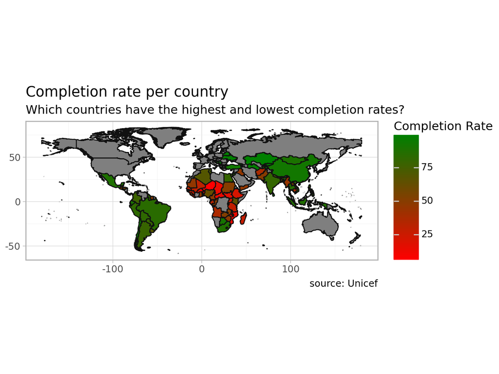

```python
shape_world = gp.read_file("https://public.opendatasoft.com/api/explore/v2.1/catalog/datasets/world-administrative-boundaries/exports/shp")

country_code = pl.read_csv("https://raw.githubusercontent.com/adrivsh/country_names/refs/heads/master/names_to_iso.csv")
UNICEF1 = (UNICEF.join(country_code, on="country", how="left"))

MapRate = (UNICEF1
  .filter(pl.col("sex") == 'Total')
)

print(MapRate.columns)
MapRateData = (shape_world
  .merge(MapRate.to_pandas(), on="iso3", how="outer")
)

(ggplot(data=MapRateData)
  + aes(fill="completion_rate")
  + geom_map()
  + coord_fixed()
  + scale_fill_gradient(low="red", high="green")
  +theme_light()
  + labs(
      title="Completion rate per country",
      subtitle = "Which countries have the highest and lowest completion rates?",
      caption="source: Unicef",
      fill="Completion Rate"

      )
)
```

**The countries with the lowest completion rate are located in Africa.**

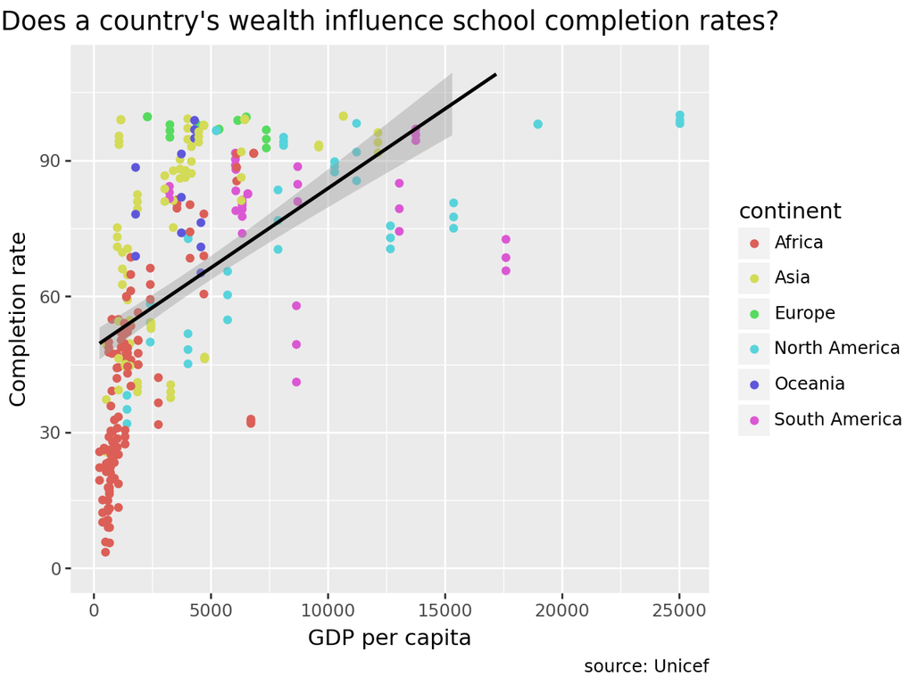

```python
(ggplot(data=UNICEF)
  + aes(x="GDP_per_capita", y="completion_rate", color="continent")
  + geom_point()
  + geom_smooth(method="lm", color="black")
  + ylim(0, 110)
  + labs(
      title="Does a country's wealth influence school completion rates?",
      caption="source: Unicef",
      x="GDP per capita",
      y="Completion rate",
)
)
```

This second visualization explores the **relationship between a country’s economic development** (measured by GDP per capita) and lower secondary school **completion rates**.

**Thanks to the trendline we see that the richest a country is, the more educated its population is going to be.**

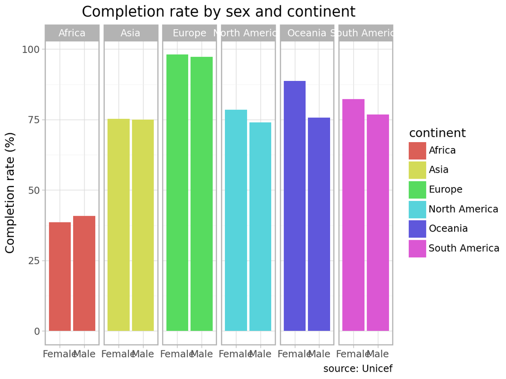

```python
PlotRate = (UNICEF
  .filter(pl.col("sex") != 'Total')
)

(ggplot(PlotRate)
+aes(x="sex",y="completion_rate",fill="continent")
+geom_col(stat="summary", fun_y=np.mean)
+facet_wrap("continent", nrow=1)
+labs(
    title="Completion rate by sex and continent",
    caption="source: Unicef",
    x="",
    y="Completion rate (%)",
 )
+theme_light()
)
```

This visualization compares lower secondary school completion rates between boys and girls **in the developing countries** of each continent. In many countries, **significant gender gaps persist.**

The gap might in average not look huge, but only because the disparities are once in way (more educated boys), once in the other (more educated girls).

The **gender gap is present** but not always visible at a continent scale.

When the gap favors **boys** it is usually due to : - early marriage - teenage pregnancy - household responsabilities.

If the gap favors **girls**, it is probably due to : - higher dropout rates for boys - boys going to get paid manual labor - boy’s recruitment into armed groups.

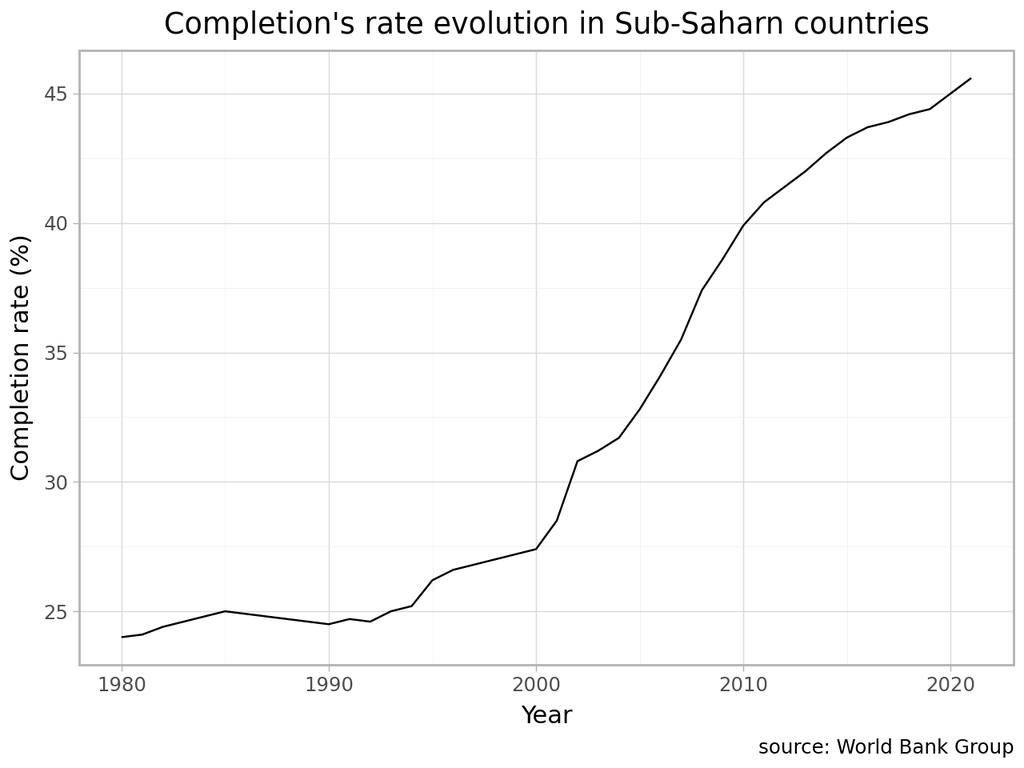

```python
(ggplot(SubSaharanRate)
+aes(x="year",y="rate")
+geom_line()
  + labs(
      title="Completion's rate evolution in Sub-Saharn countries",
      caption="source: World Bank Group",
      x="Year",
      y="Completion rate (%)",)
  +theme_light()
)
```

The region on the planet with the lowest completion rate is the Sub-Saharan countries.

Even though it is the area with the lowest rates, the completion rate has been increasing a lot in the past 20 years, so the efforts should be maintained in this direction.

[More data here](https://data.worldbank.org/indicator/SE.SEC.CMPT.LO.ZS?end=2021&locations=ZG&start=1980)

**Note**

Besides behing a poor region with an very low GDP per capita, the low completion rate is also explained by the number of conflicts in the area. The conflict lead to :  
`- destruction of educational infrastructures`, `- population migration`, `- recruitment of child soldiers`.

### *This dashboard highlights the major factors that have an impact on lower secondary school completion rates. Economic development, gender disparities, and conflict strongly influence access to education, with the lowest completion rates observed in conflict-affected and economically struggling nations.*

[To have more details on the different visualisations and the relation between armed conflicts and the completion rate](https://public.tableau.com/app/profile/l.o.cosnier/viz/Lo_Completion_Rate_Secondary/Tableaudebord1)

Source : Unicef & Africa Center for Strategic Studies & World Bank Author : Léo Cosnier